# Risk Factor Analysis

## Outcome Variable

**Outcome Variable:** haz

## Predictor Variables

**Intervention Variable:** perdiar6

**Adjustment Set:**

unadjusted

## Stratifying Variables

The analysis was stratified on these variable(s):

- agecat
- studyid
- country

## Data Summary

| agecat | studyid | country | perdiar6 | n_cell | n |
| --- | --- | --- | --- | --- | --- |
| Birth | ki0047075b-MAL-ED | BANGLADESH | 0% | 72 | 231 |
| Birth | ki0047075b-MAL-ED | BANGLADESH | (0%, 5%] | 90 | 231 |
| Birth | ki0047075b-MAL-ED | BANGLADESH | >5% | 69 | 231 |
| Birth | ki0047075b-MAL-ED | BRAZIL | 0% | 57 | 65 |
| Birth | ki0047075b-MAL-ED | BRAZIL | (0%, 5%] | 6 | 65 |
| Birth | ki0047075b-MAL-ED | BRAZIL | >5% | 2 | 65 |
| Birth | ki0047075b-MAL-ED | INDIA | 0% | 12 | 47 |
| Birth | ki0047075b-MAL-ED | INDIA | (0%, 5%] | 24 | 47 |
| Birth | ki0047075b-MAL-ED | INDIA | >5% | 11 | 47 |
| Birth | ki0047075b-MAL-ED | NEPAL | 0% | 8 | 27 |
| Birth | ki0047075b-MAL-ED | NEPAL | (0%, 5%] | 10 | 27 |
| Birth | ki0047075b-MAL-ED | NEPAL | >5% | 9 | 27 |
| Birth | ki0047075b-MAL-ED | PERU | 0% | 67 | 233 |
| Birth | ki0047075b-MAL-ED | PERU | (0%, 5%] | 72 | 233 |
| Birth | ki0047075b-MAL-ED | PERU | >5% | 94 | 233 |
| Birth | ki0047075b-MAL-ED | SOUTH AFRICA | 0% | 86 | 113 |
| Birth | ki0047075b-MAL-ED | SOUTH AFRICA | (0%, 5%] | 23 | 113 |
| Birth | ki0047075b-MAL-ED | SOUTH AFRICA | >5% | 4 | 113 |
| Birth | ki0047075b-MAL-ED | TANZANIA, UNITED REPUBLIC OF | 0% | 59 | 125 |
| Birth | ki0047075b-MAL-ED | TANZANIA, UNITED REPUBLIC OF | (0%, 5%] | 45 | 125 |
| Birth | ki0047075b-MAL-ED | TANZANIA, UNITED REPUBLIC OF | >5% | 21 | 125 |
| Birth | ki1000109-EE | PAKISTAN | 0% | 223 | 240 |
| Birth | ki1000109-EE | PAKISTAN | (0%, 5%] | 15 | 240 |
| Birth | ki1000109-EE | PAKISTAN | >5% | 2 | 240 |
| Birth | ki1017093-NIH-Birth | BANGLADESH | 0% | 160 | 605 |
| Birth | ki1017093-NIH-Birth | BANGLADESH | (0%, 5%] | 177 | 605 |
| Birth | ki1017093-NIH-Birth | BANGLADESH | >5% | 268 | 605 |
| Birth | ki1017093b-PROVIDE | BANGLADESH | 0% | 161 | 539 |
| Birth | ki1017093b-PROVIDE | BANGLADESH | (0%, 5%] | 209 | 539 |
| Birth | ki1017093b-PROVIDE | BANGLADESH | >5% | 169 | 539 |

[output cut: 87 more lines]

The following strata were considered:

- agecat: 24 months, studyid: ki0047075b-MAL-ED, country: BANGLADESH
- agecat: 24 months, studyid: ki0047075b-MAL-ED, country: BRAZIL
- agecat: 24 months, studyid: ki0047075b-MAL-ED, country: INDIA
- agecat: 24 months, studyid: ki0047075b-MAL-ED, country: NEPAL
- agecat: 24 months, studyid: ki0047075b-MAL-ED, country: PERU
- agecat: 24 months, studyid: ki0047075b-MAL-ED, country: SOUTH AFRICA
- agecat: 24 months, studyid: ki0047075b-MAL-ED, country: TANZANIA, UNITED REPUBLIC OF
- agecat: 24 months, studyid: ki1000109-EE, country: PAKISTAN
- agecat: 24 months, studyid: ki1017093-NIH-Birth, country: BANGLADESH
- agecat: 24 months, studyid: ki1017093b-PROVIDE, country: BANGLADESH
- agecat: 24 months, studyid: ki1017093c-NIH-Crypto, country: BANGLADESH
- agecat: 24 months, studyid: ki1114097-CMIN, country: BANGLADESH
- agecat: 24 months, studyid: ki1114097-CONTENT, country: PERU
- agecat: 6 months, studyid: ki0047075b-MAL-ED, country: BANGLADESH
- agecat: 6 months, studyid: ki0047075b-MAL-ED, country: BRAZIL
- agecat: 6 months, studyid: ki0047075b-MAL-ED, country: INDIA
- agecat: 6 months, studyid: ki0047075b-MAL-ED, country: NEPAL
- agecat: 6 months, studyid: ki0047075b-MAL-ED, country: PERU
- agecat: 6 months, studyid: ki0047075b-MAL-ED, country: SOUTH AFRICA
- agecat: 6 months, studyid: ki0047075b-MAL-ED, country: TANZANIA, UNITED REPUBLIC OF
- agecat: 6 months, studyid: ki1000109-EE, country: PAKISTAN
- agecat: 6 months, studyid: ki1017093-NIH-Birth, country: BANGLADESH
- agecat: 6 months, studyid: ki1017093b-PROVIDE, country: BANGLADESH
- agecat: 6 months, studyid: ki1017093c-NIH-Crypto, country: BANGLADESH
- agecat: 6 months, studyid: ki1114097-CMIN, country: BANGLADESH
- agecat: 6 months, studyid: ki1114097-CONTENT, country: PERU
- agecat: Birth, studyid: ki0047075b-MAL-ED, country: BANGLADESH
- agecat: Birth, studyid: ki0047075b-MAL-ED, country: BRAZIL
- agecat: Birth, studyid: ki0047075b-MAL-ED, country: INDIA
- agecat: Birth, studyid: ki0047075b-MAL-ED, country: NEPAL
- agecat: Birth, studyid: ki0047075b-MAL-ED, country: PERU
- agecat: Birth, studyid: ki0047075b-MAL-ED, country: SOUTH AFRICA
- agecat: Birth, studyid: ki0047075b-MAL-ED, country: TANZANIA, UNITED REPUBLIC OF
- agecat: Birth, studyid: ki1000109-EE, country: PAKISTAN
- agecat: Birth, studyid: ki1017093-NIH-Birth, country: BANGLADESH
- agecat: Birth, studyid: ki1017093b-PROVIDE, country: BANGLADESH
- agecat: Birth, studyid: ki1017093c-NIH-Crypto, country: BANGLADESH
- agecat: Birth, studyid: ki1114097-CMIN, country: BANGLADESH
- agecat: Birth, studyid: ki1114097-CONTENT, country: PERU

### Dropped Strata

Some strata were dropped due to rare outcomes:

- agecat: Birth, studyid: ki0047075b-MAL-ED, country: BRAZIL
- agecat: Birth, studyid: ki0047075b-MAL-ED, country: SOUTH AFRICA
- agecat: Birth, studyid: ki1000109-EE, country: PAKISTAN
- agecat: Birth, studyid: ki1114097-CMIN, country: BANGLADESH
- agecat: Birth, studyid: ki1114097-CONTENT, country: PERU
- agecat: 6 months, studyid: ki0047075b-MAL-ED, country: BRAZIL
- agecat: 6 months, studyid: ki1000109-EE, country: PAKISTAN
- agecat: 24 months, studyid: ki0047075b-MAL-ED, country: BRAZIL
- agecat: 24 months, studyid: ki1000109-EE, country: PAKISTAN

## Methods Detail

We’re interested in the causal parameters $E[Y_a]$ for all values of $a \in \mathcal{A}$. These parameters represent the mean outcome if, possibly contrary to fact, we intervened to set all units to have $A=a$. Under the randomization and positivity assumptions, these are identified by the statistical parameters $\psi_a=E_W[E_{Y|A,W}(Y|A=a,W)]$. In addition, we’re interested in the mean of $Y$, $E[Y]$ under no intervention (the observed mean). We will estimate these parameters by using SuperLearner to fit the relevant likelihood factors – $E_{Y|A,W}(Y|A=a,W)$ and $p(A=a|W)$, and then updating our likelihood fit using a joint TMLE.

For unadjusted analyses ($W=\{\}$), initial likelihoods were estimated using Lrnr_glm to estimate the simple $E(Y|A)$ and Lrnr_mean to estimate $p(A)$. For adjusted analyses, a small library containing Lrnr_glmnet, Lrnr_xgboost, and Lrnr_mean was used.

Having estimated these parameters, we will then use the delta method to estimate relative risks and attributable risks relative to a prespecified baseline level of $A$.

# Results Detail

## Results Plots

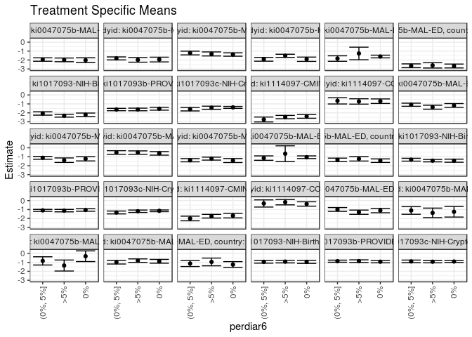

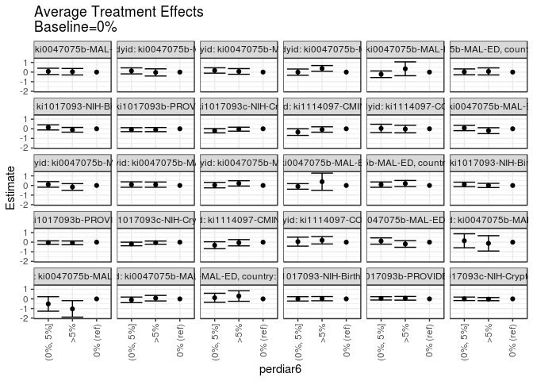

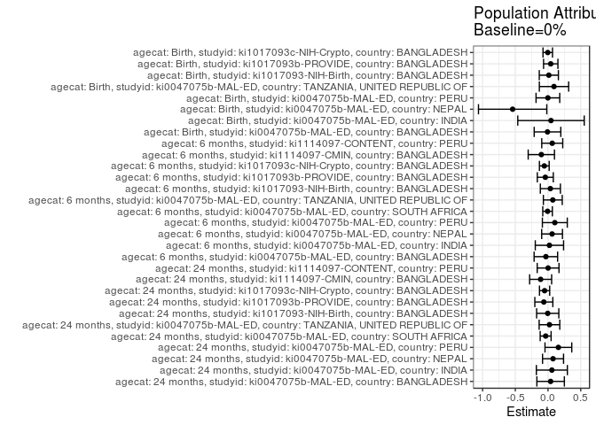

## Results Table

### Parameter: TSM

| agecat | studyid | country | intervention_level | baseline_level | estimate | ci_lower | ci_upper |
| --- | --- | --- | --- | --- | --- | --- | --- |
| Birth | ki0047075b-MAL-ED | BANGLADESH | 0% | NA | -1.1101389 | -1.3590952 | -0.8611826 |
| Birth | ki0047075b-MAL-ED | BANGLADESH | (0%, 5%] | NA | -0.9878889 | -1.1995923 | -0.7761854 |
| Birth | ki0047075b-MAL-ED | BANGLADESH | >5% | NA | -1.2962319 | -1.5325358 | -1.0599280 |
| Birth | ki0047075b-MAL-ED | INDIA | 0% | NA | -1.2491667 | -1.8412496 | -0.6570838 |
| Birth | ki0047075b-MAL-ED | INDIA | (0%, 5%] | NA | -1.1037500 | -1.5282362 | -0.6792638 |
| Birth | ki0047075b-MAL-ED | INDIA | >5% | NA | -1.3718182 | -1.9057300 | -0.8379064 |
| Birth | ki0047075b-MAL-ED | NEPAL | 0% | NA | -0.3125000 | -0.9090602 | 0.2840602 |
| Birth | ki0047075b-MAL-ED | NEPAL | (0%, 5%] | NA | -0.8360000 | -1.2964736 | -0.3755264 |
| Birth | ki0047075b-MAL-ED | NEPAL | >5% | NA | -1.3533333 | -1.9688465 | -0.7378201 |
| Birth | ki0047075b-MAL-ED | PERU | 0% | NA | -0.8807463 | -1.0921735 | -0.6693190 |
| Birth | ki0047075b-MAL-ED | PERU | (0%, 5%] | NA | -0.9820833 | -1.1828146 | -0.7813521 |
| Birth | ki0047075b-MAL-ED | PERU | >5% | NA | -0.8081915 | -1.0022876 | -0.6140954 |
| Birth | ki0047075b-MAL-ED | TANZANIA, UNITED REPUBLIC OF | 0% | NA | -1.2469492 | -1.5760364 | -0.9178619 |
| Birth | ki0047075b-MAL-ED | TANZANIA, UNITED REPUBLIC OF | (0%, 5%] | NA | -1.1308889 | -1.4632640 | -0.7985137 |
| Birth | ki0047075b-MAL-ED | TANZANIA, UNITED REPUBLIC OF | >5% | NA | -0.9519048 | -1.3845858 | -0.5192238 |
| Birth | ki1017093-NIH-Birth | BANGLADESH | 0% | NA | -0.9438750 | -1.1127457 | -0.7750043 |
| Birth | ki1017093-NIH-Birth | BANGLADESH | (0%, 5%] | NA | -0.9399435 | -1.0882498 | -0.7916372 |
| Birth | ki1017093-NIH-Birth | BANGLADESH | >5% | NA | -0.9183209 | -1.0612645 | -0.7753773 |
| Birth | ki1017093b-PROVIDE | BANGLADESH | 0% | NA | -0.9265839 | -1.0525275 | -0.8006402 |
| Birth | ki1017093b-PROVIDE | BANGLADESH | (0%, 5%] | NA | -0.8703828 | -0.9882673 | -0.7524982 |
| Birth | ki1017093b-PROVIDE | BANGLADESH | >5% | NA | -0.8637870 | -1.0106260 | -0.7169480 |
| Birth | ki1017093c-NIH-Crypto | BANGLADESH | 0% | NA | -0.9053611 | -1.0102939 | -0.8004283 |
| Birth | ki1017093c-NIH-Crypto | BANGLADESH | (0%, 5%] | NA | -0.8959509 | -1.0457689 | -0.7461329 |
| Birth | ki1017093c-NIH-Crypto | BANGLADESH | >5% | NA | -0.9271770 | -1.0547684 | -0.7995857 |
| 6 months | ki0047075b-MAL-ED | BANGLADESH | 0% | NA | -1.1720892 | -1.3845681 | -0.9596103 |
| 6 months | ki0047075b-MAL-ED | BANGLADESH | (0%, 5%] | NA | -1.0915399 | -1.2660108 | -0.9170689 |
| 6 months | ki0047075b-MAL-ED | BANGLADESH | >5% | NA | -1.3687607 | -1.5907828 | -1.1467385 |
| 6 months | ki0047075b-MAL-ED | INDIA | 0% | NA | -1.2330000 | -1.4713732 | -0.9946268 |
| 6 months | ki0047075b-MAL-ED | INDIA | (0%, 5%] | NA | -1.1209055 | -1.2797746 | -0.9620364 |
| 6 months | ki0047075b-MAL-ED | INDIA | >5% | NA | -1.3883898 | -1.6396203 | -1.1371594 |

[output cut: 60 more lines]

### Parameter: E(Y)

| agecat | studyid | country | intervention_level | baseline_level | estimate | ci_lower | ci_upper |
| --- | --- | --- | --- | --- | --- | --- | --- |
| Birth | ki0047075b-MAL-ED | BANGLADESH | NA | NA | -1.1180952 | -1.2525408 | -0.9836496 |
| Birth | ki0047075b-MAL-ED | INDIA | NA | NA | -1.2036170 | -1.4976814 | -0.9095527 |
| Birth | ki0047075b-MAL-ED | NEPAL | NA | NA | -0.8533333 | -1.2104864 | -0.4961803 |
| Birth | ki0047075b-MAL-ED | PERU | NA | NA | -0.8827897 | -1.0001058 | -0.7654736 |
| Birth | ki0047075b-MAL-ED | TANZANIA, UNITED REPUBLIC OF | NA | NA | -1.1556000 | -1.3655361 | -0.9456639 |
| Birth | ki1017093-NIH-Birth | BANGLADESH | NA | NA | -0.9314050 | -1.0202164 | -0.8425936 |
| Birth | ki1017093b-PROVIDE | BANGLADESH | NA | NA | -0.8851020 | -0.9601332 | -0.8100709 |
| Birth | ki1017093c-NIH-Crypto | BANGLADESH | NA | NA | -0.9094945 | -0.9809370 | -0.8380521 |
| 6 months | ki0047075b-MAL-ED | BANGLADESH | NA | NA | -1.2049931 | -1.3222136 | -1.0877726 |
| 6 months | ki0047075b-MAL-ED | INDIA | NA | NA | -1.2115254 | -1.3298727 | -1.0931782 |
| 6 months | ki0047075b-MAL-ED | NEPAL | NA | NA | -0.5615819 | -0.6741832 | -0.4489807 |
| 6 months | ki0047075b-MAL-ED | PERU | NA | NA | -1.3236661 | -1.4316775 | -1.2156546 |
| 6 months | ki0047075b-MAL-ED | SOUTH AFRICA | NA | NA | -1.0633202 | -1.1909180 | -0.9357224 |
| 6 months | ki0047075b-MAL-ED | TANZANIA, UNITED REPUBLIC OF | NA | NA | -1.3687449 | -1.4907629 | -1.2467270 |
| 6 months | ki1017093-NIH-Birth | BANGLADESH | NA | NA | -1.4073821 | -1.4960598 | -1.3187043 |
| 6 months | ki1017093b-PROVIDE | BANGLADESH | NA | NA | -1.0916915 | -1.1661176 | -1.0172654 |
| 6 months | ki1017093c-NIH-Crypto | BANGLADESH | NA | NA | -1.1986783 | -1.2700937 | -1.1272630 |
| 6 months | ki1114097-CMIN | BANGLADESH | NA | NA | -1.7844376 | -1.9222926 | -1.6465825 |
| 6 months | ki1114097-CONTENT | PERU | NA | NA | -0.3139217 | -0.4868486 | -0.1409948 |
| 24 months | ki0047075b-MAL-ED | BANGLADESH | NA | NA | -1.9783962 | -2.1050210 | -1.8517715 |
| 24 months | ki0047075b-MAL-ED | INDIA | NA | NA | -1.8861894 | -2.0110006 | -1.7613783 |
| 24 months | ki0047075b-MAL-ED | NEPAL | NA | NA | -1.3075877 | -1.4270718 | -1.1881037 |
| 24 months | ki0047075b-MAL-ED | PERU | NA | NA | -1.7524710 | -1.8736426 | -1.6312994 |
| 24 months | ki0047075b-MAL-ED | SOUTH AFRICA | NA | NA | -1.6450595 | -1.7797240 | -1.5103950 |
| 24 months | ki0047075b-MAL-ED | TANZANIA, UNITED REPUBLIC OF | NA | NA | -2.6455607 | -2.7807256 | -2.5103959 |
| 24 months | ki1017093-NIH-Birth | BANGLADESH | NA | NA | -2.2190579 | -2.3217459 | -2.1163699 |
| 24 months | ki1017093b-PROVIDE | BANGLADESH | NA | NA | -1.6024221 | -1.6857420 | -1.5191023 |
| 24 months | ki1017093c-NIH-Crypto | BANGLADESH | NA | NA | -1.4412646 | -1.5249156 | -1.3576135 |
| 24 months | ki1114097-CMIN | BANGLADESH | NA | NA | -2.5109504 | -2.6361514 | -2.3857494 |
| 24 months | ki1114097-CONTENT | PERU | NA | NA | -0.6962195 | -0.8674103 | -0.5250287 |

### Parameter: ATE

| agecat | studyid | country | intervention_level | baseline_level | estimate | ci_lower | ci_upper |
| --- | --- | --- | --- | --- | --- | --- | --- |
| Birth | ki0047075b-MAL-ED | BANGLADESH | 0% | 0% | 0.0000000 | 0.0000000 | 0.0000000 |
| Birth | ki0047075b-MAL-ED | BANGLADESH | (0%, 5%] | 0% | 0.1222500 | -0.2045490 | 0.4490490 |
| Birth | ki0047075b-MAL-ED | BANGLADESH | >5% | 0% | -0.1860930 | -0.5293404 | 0.1571544 |
| Birth | ki0047075b-MAL-ED | INDIA | 0% | 0% | 0.0000000 | 0.0000000 | 0.0000000 |
| Birth | ki0047075b-MAL-ED | INDIA | (0%, 5%] | 0% | 0.1454167 | -0.5831097 | 0.8739431 |
| Birth | ki0047075b-MAL-ED | INDIA | >5% | 0% | -0.1226515 | -0.9199118 | 0.6746088 |
| Birth | ki0047075b-MAL-ED | NEPAL | 0% | 0% | 0.0000000 | 0.0000000 | 0.0000000 |
| Birth | ki0047075b-MAL-ED | NEPAL | (0%, 5%] | 0% | -0.5235000 | -1.2771047 | 0.2301047 |
| Birth | ki0047075b-MAL-ED | NEPAL | >5% | 0% | -1.0408333 | -1.8980034 | -0.1836633 |
| Birth | ki0047075b-MAL-ED | PERU | 0% | 0% | 0.0000000 | 0.0000000 | 0.0000000 |
| Birth | ki0047075b-MAL-ED | PERU | (0%, 5%] | 0% | -0.1013371 | -0.3928753 | 0.1902011 |
| Birth | ki0047075b-MAL-ED | PERU | >5% | 0% | 0.0725548 | -0.2144553 | 0.3595648 |
| Birth | ki0047075b-MAL-ED | TANZANIA, UNITED REPUBLIC OF | 0% | 0% | 0.0000000 | 0.0000000 | 0.0000000 |
| Birth | ki0047075b-MAL-ED | TANZANIA, UNITED REPUBLIC OF | (0%, 5%] | 0% | 0.1160603 | -0.3516700 | 0.5837906 |
| Birth | ki0047075b-MAL-ED | TANZANIA, UNITED REPUBLIC OF | >5% | 0% | 0.2950444 | -0.2485651 | 0.8386538 |
| Birth | ki1017093-NIH-Birth | BANGLADESH | 0% | 0% | 0.0000000 | 0.0000000 | 0.0000000 |
| Birth | ki1017093-NIH-Birth | BANGLADESH | (0%, 5%] | 0% | 0.0039315 | -0.2208174 | 0.2286804 |
| Birth | ki1017093-NIH-Birth | BANGLADESH | >5% | 0% | 0.0255541 | -0.1956927 | 0.2468009 |
| Birth | ki1017093b-PROVIDE | BANGLADESH | 0% | 0% | 0.0000000 | 0.0000000 | 0.0000000 |
| Birth | ki1017093b-PROVIDE | BANGLADESH | (0%, 5%] | 0% | 0.0562011 | -0.1163056 | 0.2287078 |
| Birth | ki1017093b-PROVIDE | BANGLADESH | >5% | 0% | 0.0627969 | -0.1306546 | 0.2562484 |
| Birth | ki1017093c-NIH-Crypto | BANGLADESH | 0% | 0% | 0.0000000 | 0.0000000 | 0.0000000 |
| Birth | ki1017093c-NIH-Crypto | BANGLADESH | (0%, 5%] | 0% | 0.0094102 | -0.1735005 | 0.1923209 |
| Birth | ki1017093c-NIH-Crypto | BANGLADESH | >5% | 0% | -0.0218159 | -0.1870141 | 0.1433823 |
| 6 months | ki0047075b-MAL-ED | BANGLADESH | 0% | 0% | 0.0000000 | 0.0000000 | 0.0000000 |
| 6 months | ki0047075b-MAL-ED | BANGLADESH | (0%, 5%] | 0% | 0.0805493 | -0.1943823 | 0.3554810 |
| 6 months | ki0047075b-MAL-ED | BANGLADESH | >5% | 0% | -0.1966715 | -0.5039842 | 0.1106413 |
| 6 months | ki0047075b-MAL-ED | INDIA | 0% | 0% | 0.0000000 | 0.0000000 | 0.0000000 |
| 6 months | ki0047075b-MAL-ED | INDIA | (0%, 5%] | 0% | 0.1120945 | -0.1743687 | 0.3985577 |
| 6 months | ki0047075b-MAL-ED | INDIA | >5% | 0% | -0.1553898 | -0.5017113 | 0.1909316 |

[output cut: 60 more lines]

### Parameter: PAR

| agecat | studyid | country | intervention_level | baseline_level | estimate | ci_lower | ci_upper |
| --- | --- | --- | --- | --- | --- | --- | --- |
| Birth | ki0047075b-MAL-ED | BANGLADESH | 0% | NA | -0.0079563 | -0.2114716 | 0.1955589 |
| Birth | ki0047075b-MAL-ED | INDIA | 0% | NA | 0.0455496 | -0.4624125 | 0.5535118 |
| Birth | ki0047075b-MAL-ED | NEPAL | 0% | NA | -0.5408333 | -1.0628947 | -0.0187719 |
| Birth | ki0047075b-MAL-ED | PERU | 0% | NA | -0.0020434 | -0.1830307 | 0.1789439 |
| Birth | ki0047075b-MAL-ED | TANZANIA, UNITED REPUBLIC OF | 0% | NA | 0.0913492 | -0.1325657 | 0.3152640 |
| Birth | ki1017093-NIH-Birth | BANGLADESH | 0% | NA | 0.0124700 | -0.1335479 | 0.1584880 |
| Birth | ki1017093b-PROVIDE | BANGLADESH | 0% | NA | 0.0414818 | -0.0681338 | 0.1510975 |
| Birth | ki1017093c-NIH-Crypto | BANGLADESH | 0% | NA | -0.0041334 | -0.0768282 | 0.0685614 |
| 6 months | ki0047075b-MAL-ED | BANGLADESH | 0% | NA | -0.0329039 | -0.2125887 | 0.1467809 |
| 6 months | ki0047075b-MAL-ED | INDIA | 0% | NA | 0.0214746 | -0.1947448 | 0.2376940 |
| 6 months | ki0047075b-MAL-ED | NEPAL | 0% | NA | 0.0620639 | -0.0967751 | 0.2209029 |
| 6 months | ki0047075b-MAL-ED | PERU | 0% | NA | 0.1041158 | -0.0862477 | 0.2944793 |
| 6 months | ki0047075b-MAL-ED | SOUTH AFRICA | 0% | NA | -0.0071009 | -0.0803127 | 0.0661109 |
| 6 months | ki0047075b-MAL-ED | TANZANIA, UNITED REPUBLIC OF | 0% | NA | 0.0731439 | -0.0710519 | 0.2173398 |
| 6 months | ki1017093-NIH-Birth | BANGLADESH | 0% | NA | 0.0359125 | -0.1173818 | 0.1892068 |
| 6 months | ki1017093b-PROVIDE | BANGLADESH | 0% | NA | -0.0414383 | -0.1636862 | 0.0808096 |
| 6 months | ki1017093c-NIH-Crypto | BANGLADESH | 0% | NA | -0.0569041 | -0.1313463 | 0.0175380 |
| 6 months | ki1114097-CMIN | BANGLADESH | 0% | NA | -0.1021742 | -0.3031183 | 0.0987699 |
| 6 months | ki1114097-CONTENT | PERU | 0% | NA | 0.0644667 | -0.0959511 | 0.2248845 |
| 24 months | ki0047075b-MAL-ED | BANGLADESH | 0% | NA | 0.0396506 | -0.1704895 | 0.2497908 |
| 24 months | ki0047075b-MAL-ED | INDIA | 0% | NA | 0.0588106 | -0.1780507 | 0.2956719 |
| 24 months | ki0047075b-MAL-ED | NEPAL | 0% | NA | 0.0766980 | -0.0836138 | 0.2370097 |
| 24 months | ki0047075b-MAL-ED | PERU | 0% | NA | 0.1584095 | -0.0461144 | 0.3629334 |
| 24 months | ki0047075b-MAL-ED | SOUTH AFRICA | 0% | NA | -0.0363213 | -0.1197270 | 0.0470845 |
| 24 months | ki0047075b-MAL-ED | TANZANIA, UNITED REPUBLIC OF | 0% | NA | 0.0221023 | -0.1354849 | 0.1796895 |
| 24 months | ki1017093-NIH-Birth | BANGLADESH | 0% | NA | -0.0045875 | -0.1741095 | 0.1649346 |
| 24 months | ki1017093b-PROVIDE | BANGLADESH | 0% | NA | -0.0639682 | -0.2015835 | 0.0736471 |
| 24 months | ki1017093c-NIH-Crypto | BANGLADESH | 0% | NA | -0.0523837 | -0.1303607 | 0.0255933 |
| 24 months | ki1114097-CMIN | BANGLADESH | 0% | NA | -0.1128916 | -0.2809840 | 0.0552008 |
| 24 months | ki1114097-CONTENT | PERU | 0% | NA | 0.0012210 | -0.1653103 | 0.1677522 |